# Regresión Lineal Simple: Evaluación y Diagnóstico

Juan Barriola y Sofía Perini

26 de Septiembre de 2020

**Encuesta de Sueldos en el sector IT**

## Planteo del problema

Vamos a continuar trabajando con el dataset de la encuesta de sueldos en el sector de tecnología en Argenina realizada por SysArmy. El informe, realizado por OpenQube lo pueden ver [acá](https://sueldos.openqube.io/encuesta-sueldos-2020.01/).

El objetivo es crear un modelo lineal simple para explicar el sueldo neto de los Data Analysts, Data Scientists y Data Engineers en Argentina.

La idea subyacente de cómo se puede explicar el salario neto es:

$salarioNeto = \beta_0 +\beta_1X+\epsilon$

## Dataset y Modelos

```r
# Carga de librerías
library(tidyverse)
library(tidymodels)
```

En el notebook previo realizamos un análisis extenso de nuestro dataset, limpieza de los datos y algunos modelos para explicar el salario.

```r
# Cargamos el dataset limpio
encuesta_sueldos = read_csv("~/Fuentes/encuesta_sueldos_it_limpia.csv")
```

Habíamos realizado tres modelos distintos para tratar de explicar el salario neto

- **Modelo Edad**
- **Modelo Años de experiencia**
- **Modelo Años en la Empresa Actual**

Volvemos a realizar estos modelos:

```r
# Modelo Edad
modelo_edad = lm(formula = salario_neto ~ edad, data = encuesta_sueldos)
# Modelo experiencia
modelo_experiencia = lm(formula = salario_neto ~ anos_de_experiencia, data = encuesta_sueldos)
# Modelo empresa
modelo_empresa = lm(formula = salario_neto ~ anos_en_la_empresa_actual, data = encuesta_sueldos)
```

En el notebook previo sólo habíamos interpretado el valor de los parámetros estimados. Ahora buscaremos responder preguntas tales como:

- ¿La relación entre la variable dependiente e independiente es estadísticamente significativa?
- ¿Qué proporción de la variabilidad logra explicar el modelo? ¿Cómo decidir que modelo explica mejor el fenómeno?
- ¿El modelo cumple con los supuestos del modelo lineal?

## Tidymodels: Broom

[Tidymodels](https://www.tidymodels.org/) es un meta-paquete (al igual que `tidyverse`) que contiene varios paquetes muy útiles para crear un framework para trabajar con modelos.

El paquete [broom](https://broom.tidymodels.org/) permite acceder a información de modelos e interactuar con los mismos de una manera sencilla. Las tres funciones para interactuar con los modelos son:

- `tidy()`: resume información sobre los componentes del modelo
- `glance()`: reporta información sobre todo el modelo
- `augment()`: agrega información de las observaciones según el modelo al dataset

Veremos cómo utilizar estas funciones con un modelo lineal

## Evaluación del modelo

La función `summary()` nos permite obtener mucha información sobre el modelo lineal:

```r
resumen_modelo_edad = summary(modelo_edad)
resumen_modelo_edad
```

```
##
## Call:
## lm(formula = salario_neto ~ edad, data = encuesta_sueldos)
##
## Residuals:
##    Min     1Q Median     3Q    Max
## -44365 -16977  -3542  12294  76564
##
## Coefficients:
##             Estimate Std. Error t value Pr(>|t|)
## (Intercept)  20223.6     6983.3   2.896  0.00412 **
## edad          1364.7      223.6   6.105 4.05e-09 ***
## ---
## Signif. codes:  0 '***' 0.001 '**' 0.01 '*' 0.05 '.' 0.1 ' ' 1
##
## Residual standard error: 22100 on 243 degrees of freedom
## Multiple R-squared:  0.133,  Adjusted R-squared:  0.1294
## F-statistic: 37.27 on 1 and 243 DF,  p-value: 4.048e-09
```

Observamos que hay información sobre:

- Inferencia de $\beta_0$ y $\beta_1$
- Estimación de $\sigma^2$
- El coeficiente $R^2$
- Los residuos del modelo

En las secciones subsiguientes vamos a desarrollar cada uno de estos aspectos

### Inferencia de $\beta_1$ (test de significatividad individual)

En la salida de `summary()`, en la parte de **coefficients** observamos que están las columnas: estimate, std error, t value y Pr(>|t|). En las filas se encuentra el intercepto y la variable independiente: **edad**.

En el notebook anterior trabajamos sobre la interpretación del coeficiente estimado (estimate). Ahora nos focalizaremos en la columnas t value y Pr(>|t|).

En la inferencia de $\beta_1$ nos interesa responder si la relación entre la variable independiente y la variable a explicar es estadísticamente significativa. Nuestro test de hipótesis es:

$H_0 : \beta_1 = 0$

$H_1 : \beta_1 \neq 0$

El valor de **t value** nos indica el valor del estadístico T para este test.

El valor de **Pr(>|t|)** nos indica el p-valor para dicho test, acompañado de una ayuda visual sobre los niveles de significancia.

Como el p-valor es extremadamente pequeño concluimos que se rechaza la hipótesis nula, es decir, $\beta_1$ (parámetro poblacional) es distinto de cero.

Este test también se conoce como **test de significatividad individual** del parámetro.

#### Broom: tidy

Con la función `tidy()` del paquete broom podemos obtener la información sobre los parámetros como un dataframe:

```r
tidy(modelo_edad)
```

| term | estimate | std.error | statistic | p.value |
| --- | --- | --- | --- | --- |
| (Intercept) | 20223.59 | 6983.2576 | 2.896012 | 4.123767e-03 |
| edad | 1364.72 | 223.5562 | 6.104594 | 4.048392e-09 |

Tiene dos parámetros muy útiles:

- `conf.int`: valor lógico para incluir los intervalos de confianza o no
- `conf.level`: nivel de confianza para calcular los intervalos. Este es valor es $1 - \alpha$

```r
# Incluimos intervalos de confianza
tidy(modelo_edad,conf.int = TRUE)
```

| term | estimate | std.error | statistic | p.value | conf.low | conf.high |
| --- | --- | --- | --- | --- | --- | --- |
| (Intercept) | 20223.59 | 6983.2576 | 2.896012 | 4.123767e-03 | 6468.1529 | 33979.037 |
| edad | 1364.72 | 223.5562 | 6.104594 | 4.048392e-09 | 924.3645 | 1805.075 |

Al contar con los datos de los límites de los intervalos de confianza podemos chequear si los mismos contienen o no el cero

```r
# Aumentamos el nivel de confianza sobre los intervalos
tidy(modelo_edad,conf.int = TRUE, conf.level = 0.99)
```

| term | estimate | std.error | statistic | p.value | conf.low | conf.high |
| --- | --- | --- | --- | --- | --- | --- |
| (Intercept) | 20223.59 | 6983.2576 | 2.896012 | 4.123767e-03 | 2093.5745 | 38353.615 |
| edad | 1364.72 | 223.5562 | 6.104594 | 4.048392e-09 | 784.3204 | 1945.119 |

Al aumentar el nivel de confianza los intervalos se volvieron más anchos. De todas formas, siguen sin contener al cero.

Veamos los resultados para los otros dos modelos

**Modelo Años de experiencia**

```r
tidy(modelo_experiencia,conf.int = TRUE)
```

| term | estimate | std.error | statistic | p.value | conf.low | conf.high |
| --- | --- | --- | --- | --- | --- | --- |
| (Intercept) | 51825.264 | 1995.2856 | 25.973857 | 4.584114e-72 | 47895.001 | 55755.526 |
| anos_de_experiencia | 1693.574 | 240.2255 | 7.049934 | 1.844848e-11 | 1220.384 | 2166.764 |

Al igual que en el modelo anterior el p-valor es muy pequeño y el intervalo no contiene al cero

**Modelo Años en la Empresa Actual**

```r
tidy(modelo_empresa,conf.int = TRUE)
```

| term | estimate | std.error | statistic | p.value | conf.low | conf.high |
| --- | --- | --- | --- | --- | --- | --- |
| (Intercept) | 60301.464 | 1759.1934 | 34.277905 | 4.705258e-95 | 56836.25005 | 63766.678 |
| anos_en_la_empresa_actual | 618.576 | 336.4527 | 1.838523 | 6.720584e-02 | -44.16002 | 1281.312 |

En este modelo, el p-valor asociado al test sobre $\beta_1$ es igual a 0.067. Si nuestro nivel de significancia es 0.05 no rechazamos la hipótesis nula.

Esto también se puede observar en el intervalo de confianza asociado ya que el mismo contiene el cero.

### Test F (test de significatividad global)

```r
resumen_modelo_edad
```

```
##
## Call:
## lm(formula = salario_neto ~ edad, data = encuesta_sueldos)
##
## Residuals:
##    Min     1Q Median     3Q    Max
## -44365 -16977  -3542  12294  76564
##
## Coefficients:
##             Estimate Std. Error t value Pr(>|t|)
## (Intercept)  20223.6     6983.3   2.896  0.00412 **
## edad          1364.7      223.6   6.105 4.05e-09 ***
## ---
## Signif. codes:  0 '***' 0.001 '**' 0.01 '*' 0.05 '.' 0.1 ' ' 1
##
## Residual standard error: 22100 on 243 degrees of freedom
## Multiple R-squared:  0.133,  Adjusted R-squared:  0.1294
## F-statistic: 37.27 on 1 and 243 DF,  p-value: 4.048e-09
```

### Coeficiente de determinación $R^2$

El $R^2$ permite medir el porcentaje de variabilidad del fenómeno que el modelo logra explicar. Por este motivo es una métrica que nos permite evaluar la capacidad explicativa del modelo y poder comparar modelos entre sí bajo ciertas condiciones.

Observemos nuevamente el resumen del **Modelo Edad**

```r
resumen_modelo_edad
```

```
##
## Call:
## lm(formula = salario_neto ~ edad, data = encuesta_sueldos)
##
## Residuals:
##    Min     1Q Median     3Q    Max
## -44365 -16977  -3542  12294  76564
##
## Coefficients:
##             Estimate Std. Error t value Pr(>|t|)
## (Intercept)  20223.6     6983.3   2.896  0.00412 **
## edad          1364.7      223.6   6.105 4.05e-09 ***
## ---
## Signif. codes:  0 '***' 0.001 '**' 0.01 '*' 0.05 '.' 0.1 ' ' 1
##
## Residual standard error: 22100 on 243 degrees of freedom
## Multiple R-squared:  0.133,  Adjusted R-squared:  0.1294
## F-statistic: 37.27 on 1 and 243 DF,  p-value: 4.048e-09
```

Existen dos valores de $R^2$ en esta salida: el R-cuadrado multiple y el R-cuadrado ajustado. Podemos observar cualquiera de los dos valores ya que estamos trabajando con modelos con una sola variable independiente, el R-cuadrado ajustado tendrá mayor utilidad cuando trabajemos con regresiones múltiples.

El valor de $R^2$ es 0.1329667 (el que corresponde al R-cuadrado multiple)

#### Broom: glance

Con la función `glance()` del paquete broom podemos obtener la información sobre la evaluación global del modelo como un dataframe:

```r
glance(modelo_edad)
```

| r.squared | adj.r.squared | sigma | statistic | p.value | df | logLik | AIC | BIC | deviance | df.residual | nobs |
| --- | --- | --- | --- | --- | --- | --- | --- | --- | --- | --- | --- |
| 0.1329667 | 0.1293987 | 22102.9 | 37.26607 | 4.048392e-09 | 1 | -2797.485 | 5600.969 | 5611.473 | 118714747689 | 243 | 245 |

La salida de la función `glance()` devuelve mucha más información que la disponible en el resumen del modelo.

Veamos los resultados para los otros dos modelos

**Modelo Años de experiencia**

```r
glance(modelo_experiencia)
```

| r.squared | adj.r.squared | sigma | statistic | p.value | df | logLik | AIC | BIC | deviance | df.residual | nobs |
| --- | --- | --- | --- | --- | --- | --- | --- | --- | --- | --- | --- |
| 0.1698029 | 0.1663864 | 21628.28 | 49.70157 | 1.844848e-11 | 1 | -2792.166 | 5590.333 | 5600.836 | 113671118890 | 243 | 245 |

**Modelo Años en la Empresa Actual**

```r
glance(modelo_empresa)
```

| r.squared | adj.r.squared | sigma | statistic | p.value | df | logLik | AIC | BIC | deviance | df.residual | nobs |
| --- | --- | --- | --- | --- | --- | --- | --- | --- | --- | --- | --- |
| 0.01371931 | 0.00966054 | 23573.91 | 3.380165 | 0.06720584 | 1 | -2813.27 | 5632.541 | 5643.044 | 135042182398 | 243 | 245 |

## Diagnóstico del modelo

El diagnóstico del modelo consiste en utilizar técnicas para validar el cumplimiento o no de los supuestos del modelo lineal.

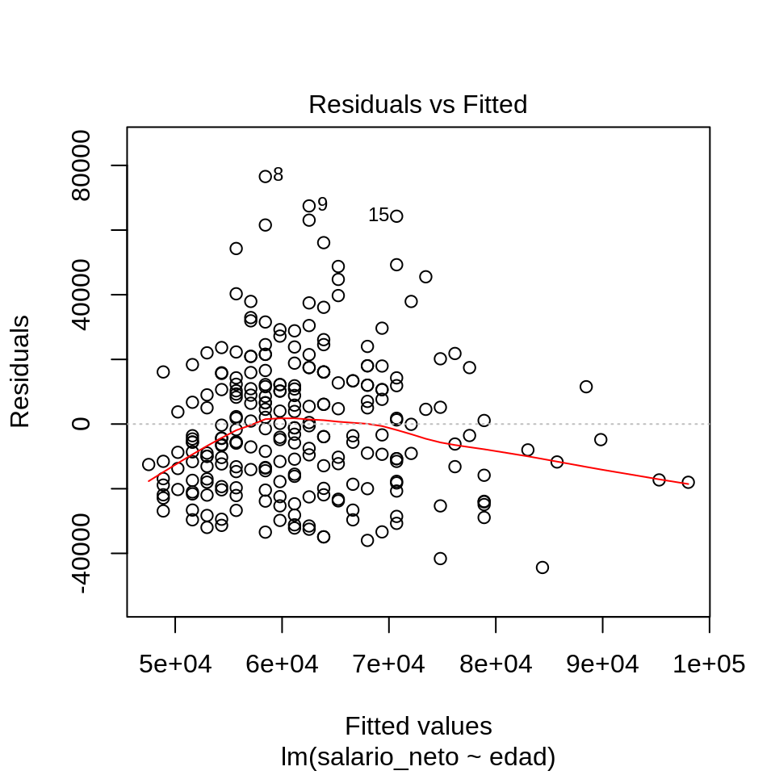

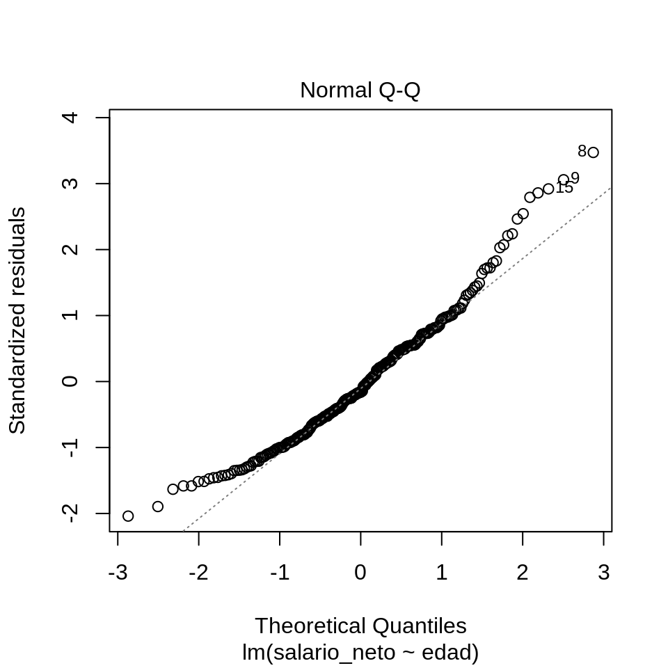

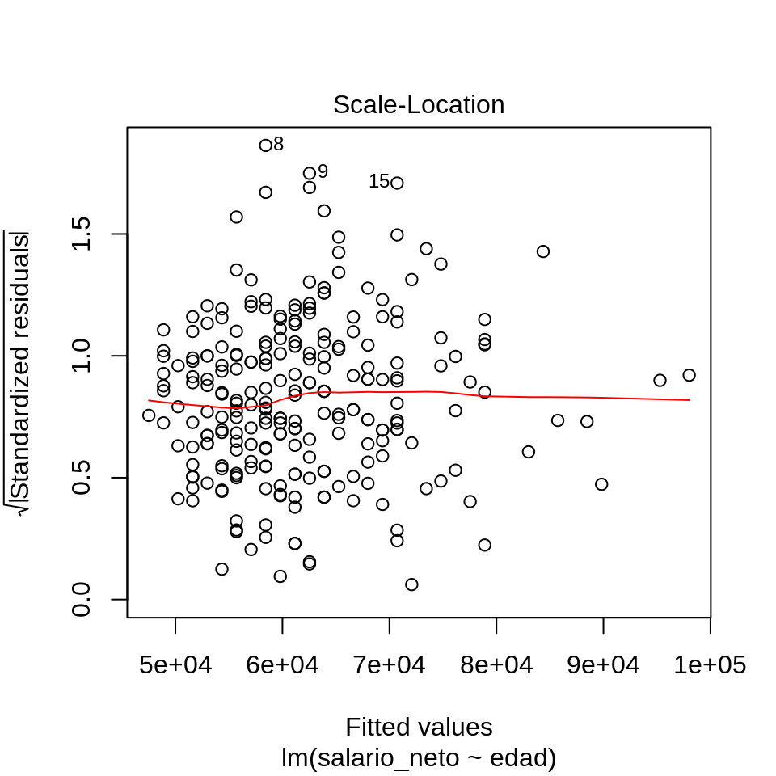

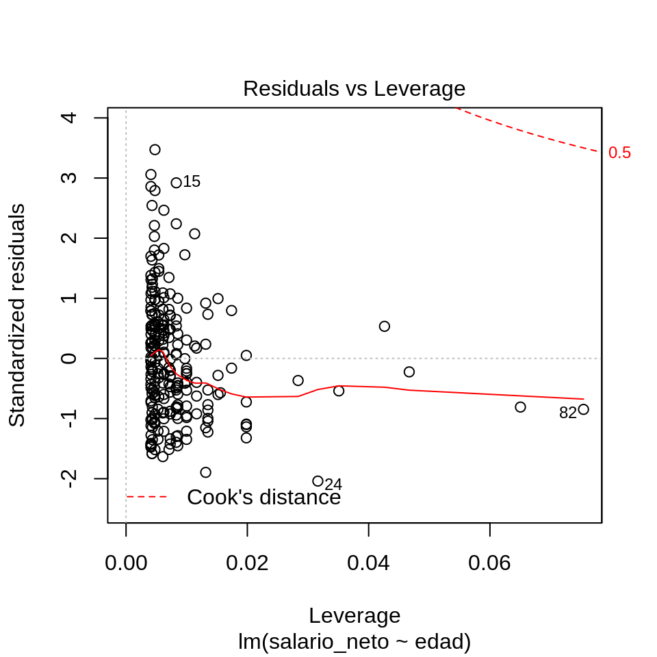

```r
plot(modelo_edad)
```

Estos gráficos son:

- Residuos versus el modelo ajustado: El objetivo es que no veamos una estructura clara. Si así la hubiera, esto implicaría que hay una parte **sistemática** del fenómeno que se esta perdiendo.
- Normal QQ plot: sirve para ver si los datos siguen una distribución teórica, en este caso, la $\sim N(0,1)$. Los residuos estandarizados, si el modelo esta bien definido, deberían seguir esta distribución
- Scale-location plot: Similar al primer gráfico, pero utilizando la raíz cuadrada de los residuos estandarizados. De la misma forma que el anterior, buscamos que no haya una estructura en los residuos.
- residual vs leverage: El leverage mide cuan influyentes son los puntos en el modelo. Si en este gráfico algunas observaciones aparecen muy separadas, con mucho leverage y residuo, significa que cambian mucho al modelo.

```r
au = augment(modelo_edad, encuesta_sueldos)
au
```

| edad | anos_de_experiencia | anos_en_la_empresa_actual | anos_en_el_puesto_actual | perfil | salario_bruto | salario_neto | .fitted | .resid | .std.resid | .hat | .sigma | .cooksd |
| --- | --- | --- | --- | --- | --- | --- | --- | --- | --- | --- | --- | --- |
| 28 | 2 | 2 | 2 | BI Analyst / Data Analyst | 43000 | 38000 | 58435.75 | -20435.75060 | -0.926785888 | 0.004768844 | 22109.34 | 2.057870e-03 |
| 34 | 9 | 5 | 5 | BI Analyst / Data Analyst | 140000 | 80000 | 66624.07 | 13375.93032 | 0.606767301 | 0.005269905 | 22131.73 | 9.752408e-04 |
| 28 | 3 | 1 | 3 | BI Analyst / Data Analyst | 54000 | 45000 | 58435.75 | -13435.75060 | -0.609327462 | 0.004768844 | 22131.59 | 8.895301e-04 |
| 31 | 12 | 0 | 0 | BI Analyst / Data Analyst | 55000 | 40000 | 62529.91 | -22529.91014 | -1.021414702 | 0.004098676 | 22100.92 | 2.146849e-03 |
| 28 | 2 | 1 | 1 | BI Analyst / Data Analyst | 41700 | 34600 | 58435.75 | -23835.75060 | -1.080979980 | 0.004768844 | 22095.20 | 2.799590e-03 |
| 29 | 3 | 2 | 3 | BI Analyst / Data Analyst | 50000 | 42000 | 59800.47 | -17800.47045 | -0.807099237 | 0.004340855 | 22118.81 | 1.420000e-03 |
| 28 | 5 | 0 | 0 | Data Scientist / Data Engineer | 220000 | 120000 | 58435.75 | 61564.24940 | 2.792012814 | 0.004768844 | 21790.36 | 1.867643e-02 |
| 28 | 7 | 0 | 0 | Data Scientist / Data Engineer | 208000 | 135000 | 58435.75 | 76564.24940 | 3.472280869 | 0.004768844 | 21592.06 | 2.888610e-02 |
| 31 | 8 | 1 | 6 | BI Analyst / Data Analyst | 190000 | 130000 | 62529.91 | 67470.08986 | 3.058820087 | 0.004098676 | 21717.93 | 1.925330e-02 |
| 35 | 5 | 13 | 2 | BI Analyst / Data Analyst | 70000 | 59000 | 67988.79 | -8988.78953 | -0.407919067 | 0.006069514 | 22140.93 | 5.080611e-04 |

[output cut: 235 more lines]

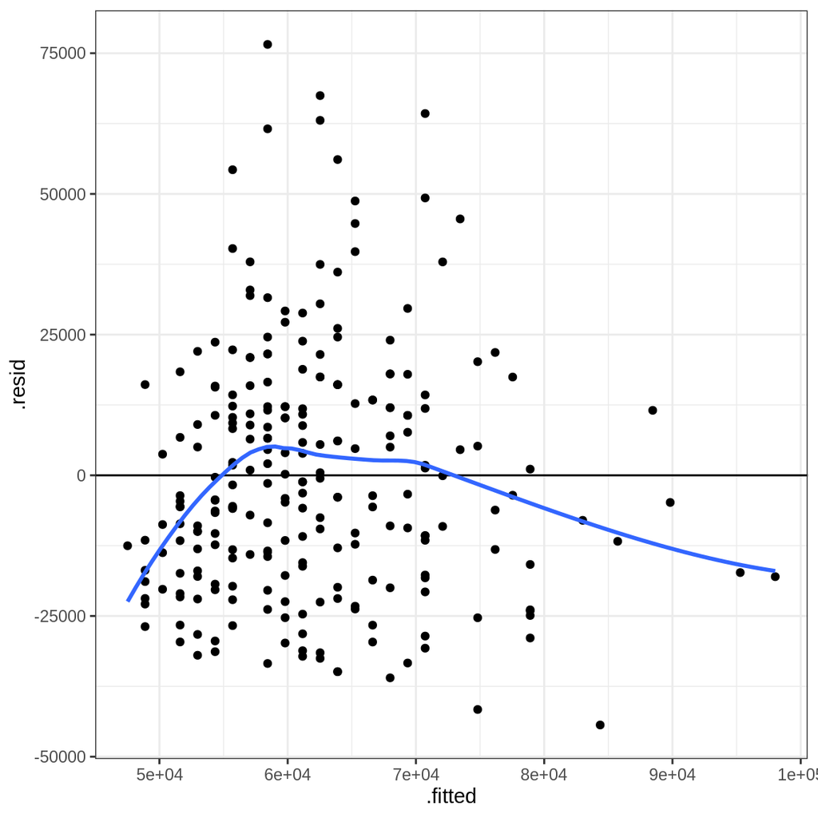

```r
ggplot(au, aes(.fitted, .resid)) +
  geom_point()+
  geom_hline(yintercept = 0) +
  geom_smooth(se = FALSE) +
  theme_bw()
```

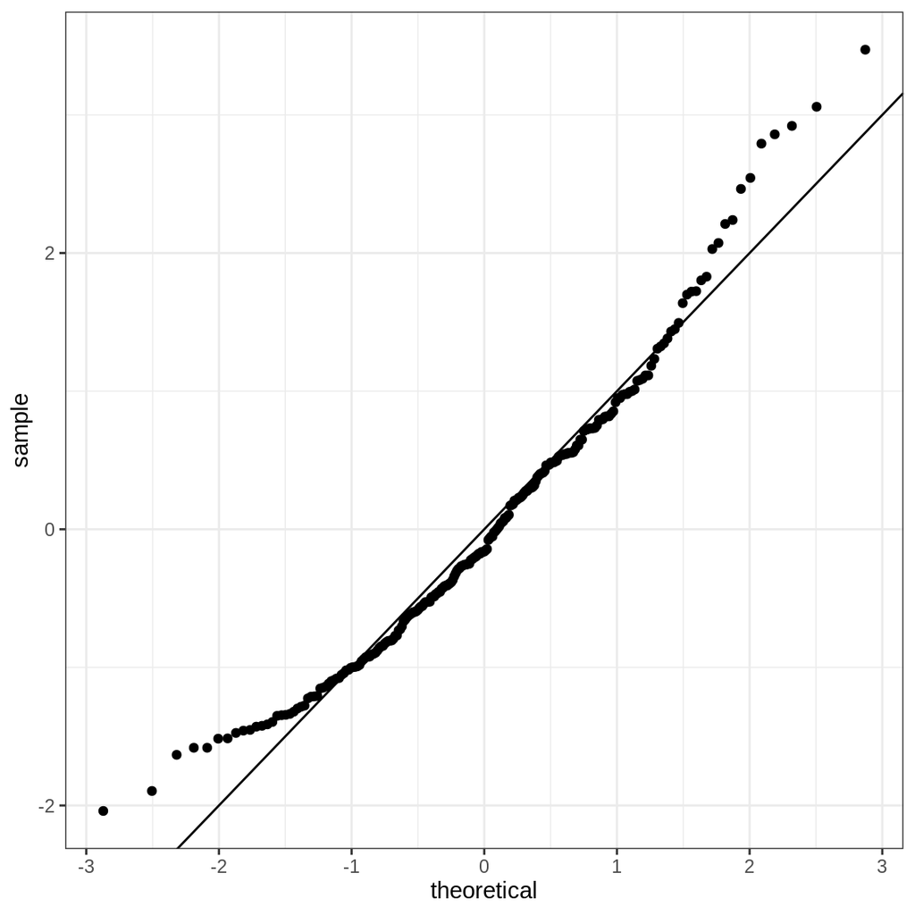

```r
ggplot(au, aes(sample= .std.resid))+
  stat_qq()+
  geom_abline() +
  theme_bw()
```

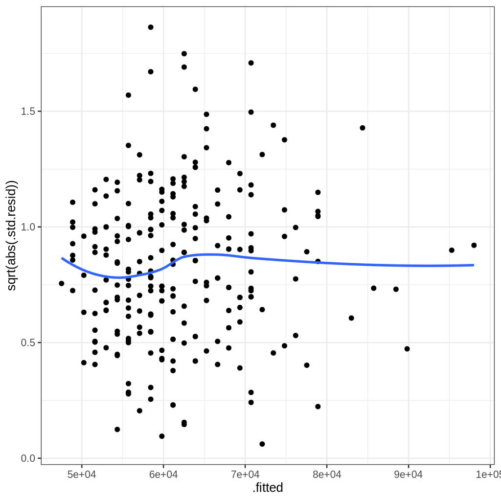

```r
ggplot(au, aes(.fitted, sqrt(abs(.std.resid))))+
  geom_point()+
  geom_smooth(se = FALSE) +
  theme_bw()
```

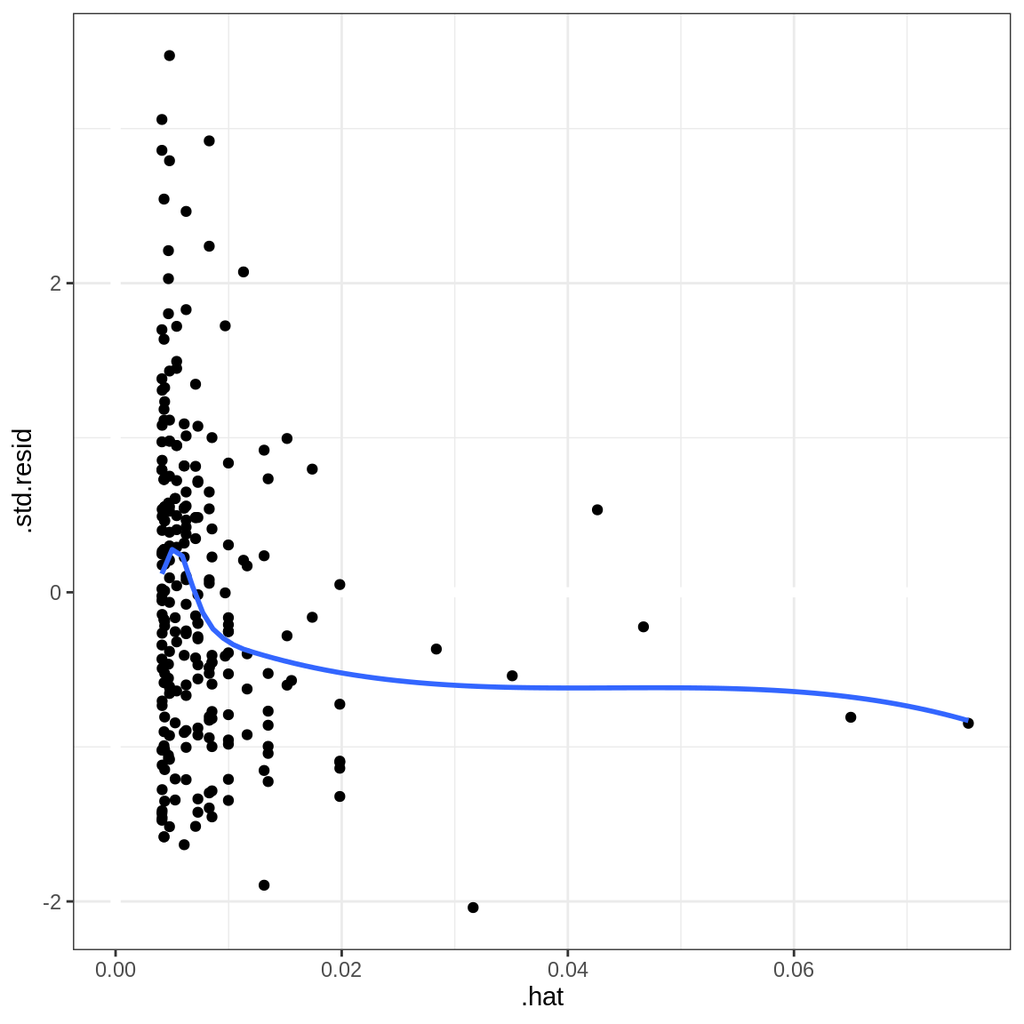

```r
ggplot(au, aes(.hat, .std.resid)) +
  geom_vline(size = 2, colour = "white", xintercept = 0) +
  geom_hline(size = 2, colour = "white", yintercept = 0) +
  geom_point() + geom_smooth(se = FALSE) +
  theme_bw()
```